# Trabalho_D6

## Gráfico 1: número de adesões ao SNC por ano

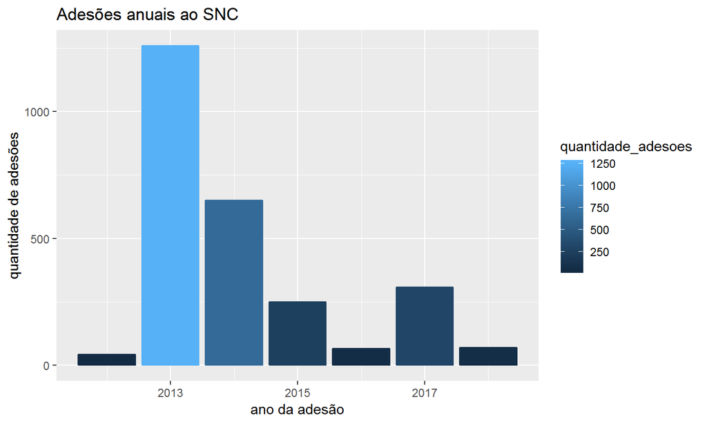

```r
ggplot(adesoes_ano) +
  geom_bar(aes(x = ano_adesao, y = quantidade_adesoes, color=quantidade_adesoes, fill=quantidade_adesoes), stat = "identity") +
  labs(title="Adesões anuais ao SNC", x="ano da adesão", y="quantidade de adesões")
```

## base de dados "Adesao"

## Leitura da base de dados "Adesao"

```r
adesao <- read_xlsx("E:/D6/Dados_trabalho/Adesao.xlsx")
```

```r
str(adesao)
```

```
## Classes 'tbl_df', 'tbl' and 'data.frame':    3044 obs. of  9 variables:
##  $ UF                      : chr  "DF" "ES" "PR" "SE" ...
##  $ Ente                    : chr  "Distrito Federal" "Espírito Santo" "Paraná" "Sergipe" ...
##  $ Codigo                  : num  53 32 41 28 52 24 25 42 35 12 ...
##  $ Situação                : chr  "Publicado no DOU" "Publicado no DOU" "Publicado no DOU" "Publicado no DOU" ...
##  $ Possui_Sistema          : chr  "Não" "Não" "Não" "Sim" ...
##  $ Possui_Órgão_Gestor     : chr  "Não" "Sim" "Não" "Não" ...
##  $ Possui_Conselho         : chr  "Não" "Sim" "Não" "Sim" ...
##  $ Possui_Mecanismo_Fomento: chr  "Não" "Sim" "Não" "Sim" ...
##  $ Possui_Plano            : chr  "Não" "Sim" "Não" "Não" ...
```

```r
View(adesao)
```

## Quantidade de entes federados em relação à situação da adesão ao SNC

```r
situacao <- adesao %>%
  group_by(Situação) %>%
  count(Situação)
```

```r
situacao
```

```
## # A tibble: 4 x 2
## # Groups:   Situação [4]
##   Situação                                          n
##   <chr>                                         <int>
## 1 Aguardando envio da documentação                186
## 2 Aguardando preenchimento dos dados cadastrais    71
## 3 Diligência Documental                            92
## 4 Publicado no DOU                               2695
```

## Quantidade de entes federados com adesao publicada e que constituíram sistema local de cultura

```r
publicado <-  adesao %>%
  select(UF, Ente, Situação, Possui_Sistema) %>%
  filter(Situação == "Publicado no DOU" & Possui_Sistema == "Sim") %>%
  count(Possui_Sistema)
```

```r
publicado
```

```
## # A tibble: 1 x 2
##   Possui_Sistema     n
##   <chr>          <int>
## 1 Sim              347
```

## Quantidade de entes federados com adesão publicada e que possuem órgão gestor local

```r
org_gestor <- adesao %>%
  select(UF, Ente, Situação, Possui_Órgão_Gestor) %>%
  filter(Situação == "Publicado no DOU" & Possui_Órgão_Gestor == "Sim") %>%
  count(Possui_Órgão_Gestor)
```

```r
org_gestor
```

```
## # A tibble: 1 x 2
##   Possui_Órgão_Gestor     n
##   <chr>               <int>
## 1 Sim                   345
```

## Quantidade de entes federados com adesao publicada e que instituíram Conselho de política cultural

```r
conselho <- adesao %>%
  select(UF, Ente, Situação, Possui_Conselho) %>%
  filter(Situação == "Publicado no DOU" & Possui_Conselho == "Sim") %>%
  count(Possui_Conselho)
```

```r
conselho
```

```
## # A tibble: 1 x 2
##   Possui_Conselho     n
##   <chr>           <int>
## 1 Sim               296
```

## Quantidade de entes federados com adesão publicada e que definiram mecanismo para fomento da cultura

```r
mec_fomento <- adesao %>%
  select(UF, Ente, Situação, Possui_Mecanismo_Fomento) %>%
  filter(Situação == "Publicado no DOU" & Possui_Mecanismo_Fomento == "Sim") %>%
  count(Possui_Mecanismo_Fomento)
```

```r
mec_fomento
```

```
## # A tibble: 1 x 2
##   Possui_Mecanismo_Fomento     n
##   <chr>                    <int>
## 1 Sim                        246
```

## Quantidade de entes federados com adesão publicada e que elaboraram plano de política cultural

```r
plano <- adesao %>%
  select(UF, Ente, Situação, Possui_Plano) %>%
  filter(Situação == "Publicado no DOU" & Possui_Plano == "Sim") %>%
  count(Possui_Plano)
```

```r
plano
```

```
## # A tibble: 1 x 2
##   Possui_Plano     n
##   <chr>        <int>
## 1 Sim            142
```